# Periodical Exam - 1 Indian Statistical Inst- Hyderabad

### Generalized Linear Model techniques

#### CASE 1 : Bootstrap

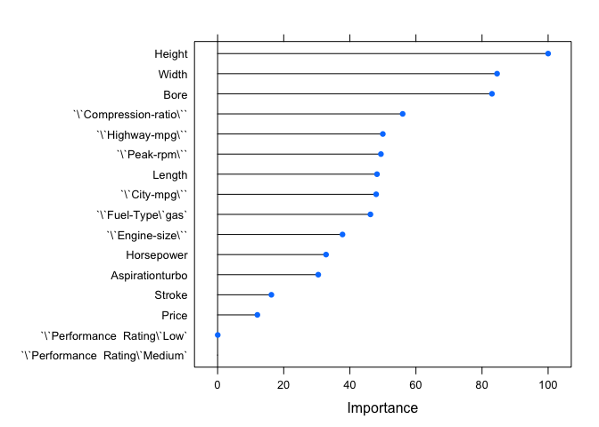

```r
# Build a logistic regression model
auto_glm_pm <- train(`Emission Standards` ~ ., method = "glm", family = "binomial",
                   data = training_cars,
                   trControl = trainControl(method = "boot"))

imp_var_sflow <- varImp(auto_glm_pm)

plot(imp_var_sflow)
```

```r
# Confusion matrix for logistic regression model - Training data
confusionMatrix(predict(auto_glm_pm, training_cars), training_cars$`Emission Standards`)
```

```
## Confusion Matrix and Statistics
##
##              Reference
## Prediction    Meeting Not Meeting
##   Meeting          76           9
##   Not Meeting      11          60
##
##                Accuracy : 0.8718
##                  95% CI : (0.809, 0.9199)
##     No Information Rate : 0.5577
##     P-Value [Acc > NIR] : <2e-16
##
##                   Kappa : 0.7409
##  Mcnemar's Test P-Value : 0.8231
##
##             Sensitivity : 0.8736
##             Specificity : 0.8696
##          Pos Pred Value : 0.8941
##          Neg Pred Value : 0.8451
##              Prevalence : 0.5577
##          Detection Rate : 0.4872
##    Detection Prevalence : 0.5449
##       Balanced Accuracy : 0.8716
##
##        'Positive' Class : Meeting
##
```

```r
# Confusion matrix for logistic regression model - Testing data
confusionMatrix(predict(auto_glm_pm, testing_cars), testing_cars$`Emission Standards`)
```

```
## Confusion Matrix and Statistics
##
##              Reference
## Prediction    Meeting Not Meeting
##   Meeting          15           1
##   Not Meeting       4          19
##
##                Accuracy : 0.8718
##                  95% CI : (0.7257, 0.957)
##     No Information Rate : 0.5128
##     P-Value [Acc > NIR] : 2.544e-06
##
##                   Kappa : 0.7424
##  Mcnemar's Test P-Value : 0.3711
##
##             Sensitivity : 0.7895
##             Specificity : 0.9500
##          Pos Pred Value : 0.9375
##          Neg Pred Value : 0.8261
##              Prevalence : 0.4872
##          Detection Rate : 0.3846
##    Detection Prevalence : 0.4103
##       Balanced Accuracy : 0.8697
##
##        'Positive' Class : Meeting
##
```

#### CASE 2 : K-Fold cross validation

```r
# Build a logistic regression model
auto_glm_pm_cv <- train(`Emission Standards` ~ ., method = "glm", family = "binomial",
                   data = training_cars,
                   trControl = trainControl(method = "cv",sampling = "up"))
```

```r
# Confusion matrix for logistic regression model
confusionMatrix(predict(auto_glm_pm_cv, testing_cars), testing_cars$`Emission Standards`)
```

```
## Confusion Matrix and Statistics
##
##              Reference
## Prediction    Meeting Not Meeting
##   Meeting          15           1
##   Not Meeting       4          19
##
##                Accuracy : 0.8718
##                  95% CI : (0.7257, 0.957)
##     No Information Rate : 0.5128
##     P-Value [Acc > NIR] : 2.544e-06
##
##                   Kappa : 0.7424
##  Mcnemar's Test P-Value : 0.3711
##
##             Sensitivity : 0.7895
##             Specificity : 0.9500
##          Pos Pred Value : 0.9375
##          Neg Pred Value : 0.8261
##              Prevalence : 0.4872
##          Detection Rate : 0.3846
##    Detection Prevalence : 0.4103
##       Balanced Accuracy : 0.8697
##
##        'Positive' Class : Meeting
##
```

*Interpretation*

> Overall accuracy is calculated at just over 87%, the classifier seems to be doing a pretty reasonable job of classifying items.

> Sensitivity and specificity respectively help us measure the performance of the classifier in correctly predicting the actual class of an item and not predicting the class of an item that is of a different class; it measures true positive and true negative performance.

> From the above data we can see that our classifier correctly identified class Meeting 78% of the time. That is, when we should have predicted class Meeting we did. Further, when we shouldn’t have predicted class Meeting we didn’t for 95%.

> Class Meeting has a positive predictive value of over 93%: despite our classifier only being able to positively identify objects 78% of the time there’s a 93% chance that, when it does, such a classification is correct.

### Applyting Linear Discriminent Analysis Technique

```r
# Model Fitting

# Build a Linear Discriminent Analysis
auto_glm_ra <- train(`Performance  Rating` ~ ., method = "lda",
                   data = training_cars,
                   trControl = trainControl(method = "cv"))
```

```r
# Confusion matrix for Linear Discriminent Analysis
confusionMatrix(predict(auto_glm_ra, training_cars), training_cars$`Performance  Rating`)
```

```
## Confusion Matrix and Statistics
##
##           Reference
## Prediction High Low Medium
##     High     32   0      7
##     Low       0  10      2
##     Medium   13   8     84
##
## Overall Statistics
##
##                Accuracy : 0.8077
##                  95% CI : (0.737, 0.8663)
##     No Information Rate : 0.5962
##     P-Value [Acc > NIR] : 1.373e-08
##
##                   Kappa : 0.6286
##  Mcnemar's Test P-Value : NA
##
## Statistics by Class:
##
##                      Class: High Class: Low Class: Medium
## Sensitivity               0.7111    0.55556        0.9032
## Specificity               0.9369    0.98551        0.6667
## Pos Pred Value            0.8205    0.83333        0.8000
## Neg Pred Value            0.8889    0.94444        0.8235
## Prevalence                0.2885    0.11538        0.5962
## Detection Rate            0.2051    0.06410        0.5385
## Detection Prevalence      0.2500    0.07692        0.6731
## Balanced Accuracy         0.8240    0.77053        0.7849
```

```r
confusionMatrix(predict(auto_glm_ra, testing_cars), testing_cars$`Performance  Rating`)
```

```
## Confusion Matrix and Statistics
##
##           Reference
## Prediction High Low Medium
##     High      7   0      1
##     Low       0   2      0
##     Medium    2   5     22
##
## Overall Statistics
##
##                Accuracy : 0.7949
##                  95% CI : (0.6354, 0.907)
##     No Information Rate : 0.5897
##     P-Value [Acc > NIR] : 0.00577
##
##                   Kappa : 0.5937
##  Mcnemar's Test P-Value : NA
##
## Statistics by Class:
##
##                      Class: High Class: Low Class: Medium
## Sensitivity               0.7778    0.28571        0.9565
## Specificity               0.9667    1.00000        0.5625
## Pos Pred Value            0.8750    1.00000        0.7586
## Neg Pred Value            0.9355    0.86486        0.9000
## Prevalence                0.2308    0.17949        0.5897
## Detection Rate            0.1795    0.05128        0.5641
## Detection Prevalence      0.2051    0.05128        0.7436
## Balanced Accuracy         0.8722    0.64286        0.7595
```

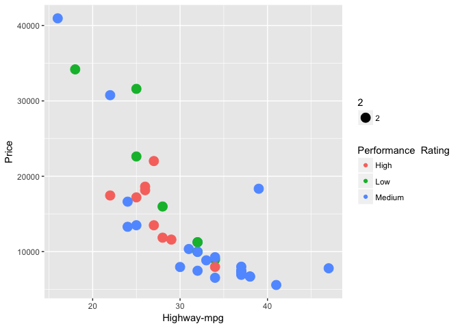

```r
# Visualization
qplot(`Highway-mpg`, Price, data=testing_cars, cex=2, col=`Performance  Rating`)
```

*Interpretation*

> From the above data we can say that our classifier correctly identified class Medium 95% of the time and class High 77% of the time

> Class High has a positive predictive value of over 87%: despite our classifier only being able to positively identify objects 77% of the time there’s a 87% chance that, when it does, such a classification is correct.